# Statistiek - Lab session 5

J.F.P. (Richard) (s2956586)

Generated on: Thu May 03 15:25:05 2018

```r
download.file('http://www.let.rug.nl/wieling/Statistiek-I/satsfull.rda','sats.rda')
load('sats.rda',verbose=T)
```

```
## Loading objects:
##   sats
```

# 1 Excercise 1

```r
str(sats)
```

```
## 'data.frame':    315 obs. of  51 variables:
##  $ participant : int  1 2 3 4 5 6 7 8 9 10 ...
##  $ year        : num  2016 2016 2016 2016 2016 ...
##  $ gender      : Factor w/ 2 levels "F","M": 1 2 2 1 1 1 1 2 1 1 ...
##  $ hand        : Factor w/ 2 levels "R","L": 1 2 1 1 1 1 1 1 1 1 ...
##  $ instrument  : Factor w/ 2 levels "Y","N": 1 1 2 1 2 2 2 1 1 1 ...
##  $ study       : Factor w/ 4 levels "CIS","IS","LING",..: 3 2 3 1 1 3 1 3 3 1 ...
##  $ edu_level   : Factor w/ 3 levels "HAVO","VWO","HBO": 2 2 1 2 3 2 3 1 2 3 ...
##  $ bl_edu      : Factor w/ 2 levels "Y","N": 2 2 2 2 2 2 2 2 2 2 ...
##  $ spk_frisian : Factor w/ 2 levels "Y","N": 2 2 2 2 2 2 2 2 1 2 ...
##  $ WA_grade    : num  7 NA 7 6 7 NA NA 7.6 7 NA ...
##  $ WB_grade    : num  NA 6 NA NA NA 8 5 NA NA NA ...
##  $ WC_grade    : num  NA NA NA NA NA NA NA NA NA NA ...
##  $ WD_grade    : num  NA NA NA NA NA NA NA NA NA NA ...
##  $ Q1          : num  7 6 7 6 6 7 6 7 7 7 ...
```

[output cut: 37 more lines]

```r
head(sats)
```

```
##   participant year gender hand instrument study edu_level bl_edu
## 1           1 2016      F    R          Y  LING       VWO      N
## 2           2 2016      M    L          Y    IS       VWO      N
## 3           3 2016      M    R          N  LING      HAVO      N
## 4           4 2016      F    R          Y   CIS       VWO      N
## 5           5 2016      F    R          N   CIS       HBO      N
## 6           6 2016      F    R          N  LING       VWO      N
##   spk_frisian WA_grade WB_grade WC_grade WD_grade Q1 Q2 Q3 Q4 Q5 Q6 Q7 Q8
## 1           N        7       NA       NA       NA  7  7  7  1  1  6  1  1
## 2           N       NA        6       NA       NA  6  5  4  4  4  5  2  5
## 3           N        7       NA       NA       NA  7  7  7  2  6  6  3  3
## 4           N        6       NA       NA       NA  6  5  4  4  3  4  3  5
## 5           N        7       NA       NA       NA  6  7  3  3  4  2  3  7
## 6           N       NA        8       NA       NA  7  6  5  4  2  5  1  4
##   Q9 Q10 Q11 Q12 Q13 Q14 Q15 Q16 Q17 Q18 Q19 Q20 Q21 Q22 Q23 Q24 Q25 Q26
## 1  6   4   1   6   1   7   1   4   5   1   7   7   5   4   6   4   6   1
## 2  5   5   3   5   4   7   5   2   4   3   3   5   4   5   6   5   2   5
## 3  7   4   3   5   5   6   2   4   1   2   6   6   5   6   6   7   5   5
## 4  4   4   5   3   4   3   4   4   3   4   4   4   4   4   4   4   3   4
## 5  4   4   4   5   3   6   6   3   2   5   2   5   3   2   6   6   3   6
## 6  4   6   5   4   2   6   4   3   4   3   6   6   4   5   5   4   4   2
##   Q27 Q28 Q29 Q30 Q31 Q32 Q33 Q34 Q35 Q36 stats_grade stats_choice
## 1   7   1   7   2   7   7   1   1   1   1         7.0            7
## 2   5   5   4   4   6   6   3   4   5   4         7.0            5
## 3   7   1   5   6   7   6   5   3   3   4         7.0            2
## 4   5   4   4   4   5   5   4   4   4   4         6.0            3
## 5   6   6   6   7   5   4   4   5   6   6         6.0            1
## 6   7   2   6   4   7   7   3   5   3   4         7.5            6
```

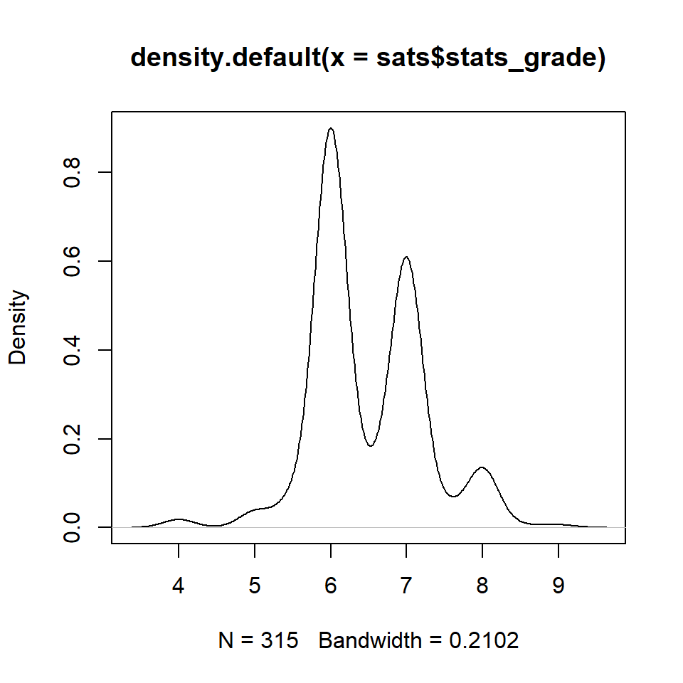

```r
plot(density(sats$stats_grade))
```

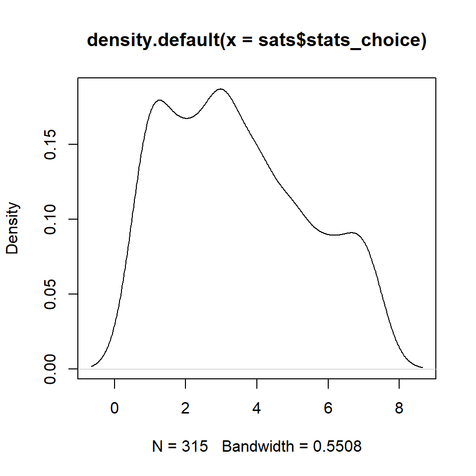

```r
plot(density(sats$stats_choice))
```

```r
sats$math_grade = rowMeans(sats[,c('WA_grade','WB_grade','WC_grade','WD_grade')],na.rm=T)
head(sats)
```

```
##   participant year gender hand instrument study edu_level bl_edu
## 1           1 2016      F    R          Y  LING       VWO      N
## 2           2 2016      M    L          Y    IS       VWO      N
## 3           3 2016      M    R          N  LING      HAVO      N
## 4           4 2016      F    R          Y   CIS       VWO      N
## 5           5 2016      F    R          N   CIS       HBO      N
## 6           6 2016      F    R          N  LING       VWO      N
##   spk_frisian WA_grade WB_grade WC_grade WD_grade Q1 Q2 Q3 Q4 Q5 Q6 Q7 Q8
## 1           N        7       NA       NA       NA  7  7  7  1  1  6  1  1
## 2           N       NA        6       NA       NA  6  5  4  4  4  5  2  5
## 3           N        7       NA       NA       NA  7  7  7  2  6  6  3  3
## 4           N        6       NA       NA       NA  6  5  4  4  3  4  3  5
## 5           N        7       NA       NA       NA  6  7  3  3  4  2  3  7
## 6           N       NA        8       NA       NA  7  6  5  4  2  5  1  4
##   Q9 Q10 Q11 Q12 Q13 Q14 Q15 Q16 Q17 Q18 Q19 Q20 Q21 Q22 Q23 Q24 Q25 Q26
```

[output cut: 20 more lines]

# 2 Excercise 2

```r
library(vcd)  # install with: install.packages('vcd')
(counts <- table(sats$instrument, sats$study))
```

```
##
##     CIS IS LING OTHER
##   Y  50 38   68    26
##   N  51 36   34    12
```

```r
(expected <- round(chisq.test(counts)$expected))
```

```
##
##     CIS IS LING OTHER
##   Y  58 43   59    22
##   N  43 31   43    16
```

```r
(rowtable <- prop.table(counts,1))
```

```
##
##            CIS         IS       LING      OTHER
##   Y 0.27472527 0.20879121 0.37362637 0.14285714
##   N 0.38345865 0.27067669 0.25563910 0.09022556
```

```r
(column <- prop.table(counts,2))
```

```
##
##           CIS        IS      LING     OTHER
##   Y 0.4950495 0.5135135 0.6666667 0.6842105
##   N 0.5049505 0.4864865 0.3333333 0.3157895
```

```r
(total <- prop.table(counts))
```

```
##
##            CIS         IS       LING      OTHER
##   Y 0.15873016 0.12063492 0.21587302 0.08253968
##   N 0.16190476 0.11428571 0.10793651 0.03809524
```

```r
(residuals <- chisq.test(sats$instrument, sats$study)$stdres)
```

```
##                sats$study
## sats$instrument       CIS        IS      LING     OTHER
##               Y -2.042265 -1.279621  2.210355  1.416549
##               N  2.042265  1.279621 -2.210355 -1.416549
```

```r
chisq.test(sats$instrument, sats$study)
```

```
##
##  Pearson's Chi-squared test
##
## data:  sats$instrument and sats$study
## X-squared = 9.1545, df = 3, p-value = 0.02731
```

```r
assocstats(counts)
```

```
##                     X^2 df P(> X^2)
## Likelihood Ratio 9.2452  3 0.026202
## Pearson          9.1545  3 0.027306
##
## Phi-Coefficient   : NA
## Contingency Coeff.: 0.168
## Cramer's V        : 0.17
```

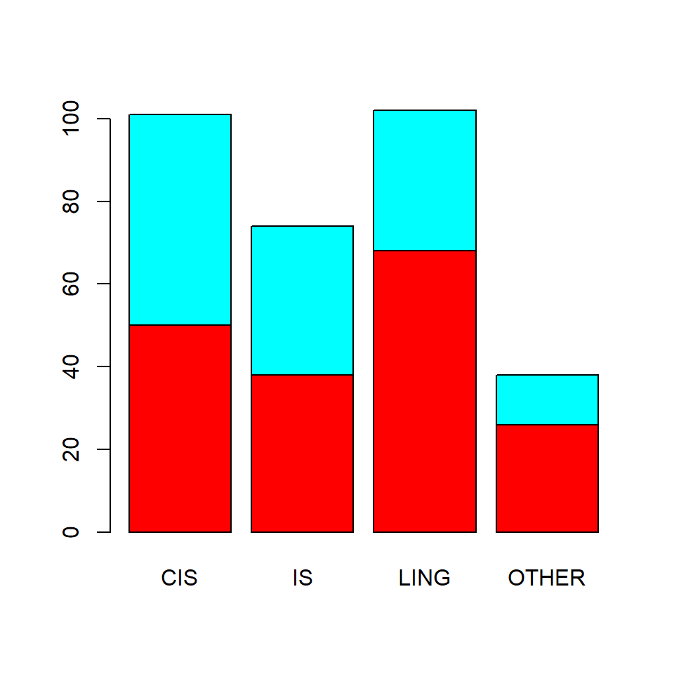

```r
barplot(counts, col=rainbow(2))
```

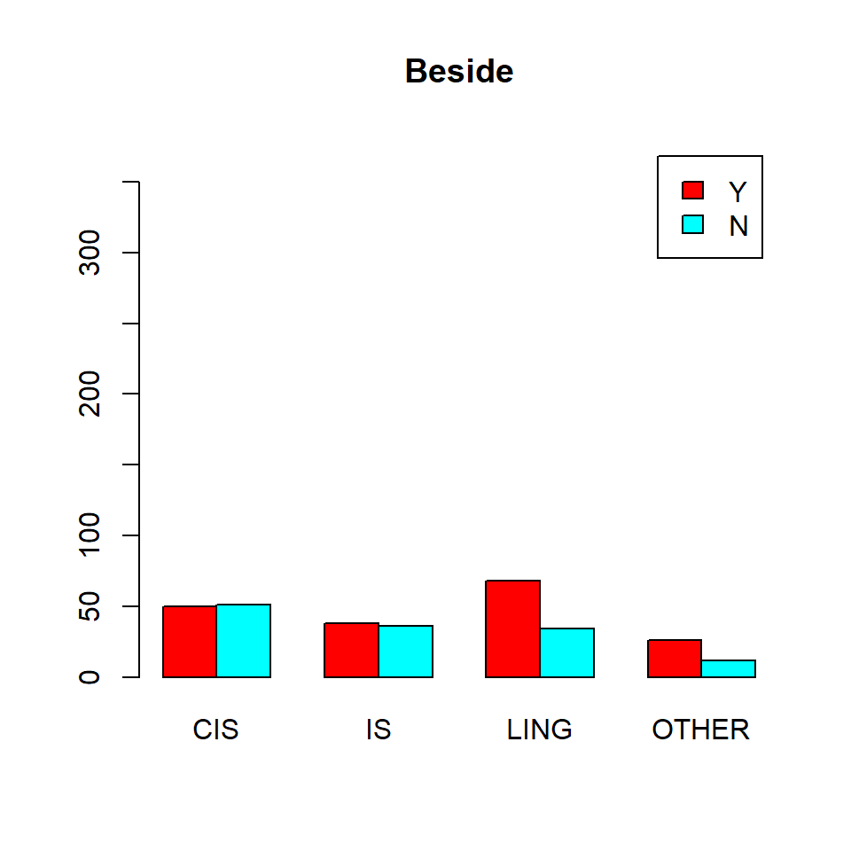

```r
barplot(counts, legend = c("Y", "N"), beside = T, ylim = c(0, 380), main = "Beside",col=rainbow(2))
```

We use a dataset wherein 315 students from the studies LING, CIS, IS etc. gave answers to the statistic questions. In this excercise we will try to see if there is a relationship between playing an instrument and the study. We use the chi square test to test the dependence of the two variables because both variables are nominal and the frequency of every combination is above 5.

H0: There is no significant relationship between playing instruments and the students chosen study. Ha: There is a significant relationship between playing instruments and the students chosen study.

H0: $\mu$i = $\mu$s

Ha: $\mu$i $\neq$ $\mu$s

Significance level: 0.05

$\chi^2$: 9.1545 df: 3 p-value: 0.02731 Contingency Coeff.: 0.168 Cramer’s V : 0.17

The p-level is lower than the significance level. Therefor H0 will be rejected and we accept Ha.

# 3 Excercise 3

```r
sats17 <- sats[sats$year == "2017", ]
(counts <- table(sats17$edu_level, sats17$study))
```

```
##
##        CIS IS LING OTHER
##   HAVO   3  4    8     3
##   VWO    3 30   26    12
##   HBO   17  0    8     0
```

```r
(expected <- round(chisq.test(counts)$expected))
```

```
##
##        CIS IS LING OTHER
##   HAVO   4  5    7     2
##   VWO   14 21   26     9
##   HBO    5  7    9     3
```

```r
(rowtable <- prop.table(counts,1))
```

```
##
##               CIS         IS       LING      OTHER
##   HAVO 0.16666667 0.22222222 0.44444444 0.16666667
##   VWO  0.04225352 0.42253521 0.36619718 0.16901408
##   HBO  0.68000000 0.00000000 0.32000000 0.00000000
```

```r
(column <- prop.table(counts,2))
```

```
##
##              CIS        IS      LING     OTHER
##   HAVO 0.1304348 0.1176471 0.1904762 0.2000000
##   VWO  0.1304348 0.8823529 0.6190476 0.8000000
##   HBO  0.7391304 0.0000000 0.1904762 0.0000000
```

```r
(total <- prop.table(counts))
```

```
##
##               CIS         IS       LING      OTHER
##   HAVO 0.02631579 0.03508772 0.07017544 0.02631579
##   VWO  0.02631579 0.26315789 0.22807018 0.10526316
##   HBO  0.14912281 0.00000000 0.07017544 0.00000000
```

```r
fisher.test(counts)
```

```
##
##  Fisher's Exact Test for Count Data
##
## data:  counts
## p-value = 2.608e-10
## alternative hypothesis: two.sided
```

```r
assocstats(counts)
```

```
##                     X^2 df   P(> X^2)
## Likelihood Ratio 57.192  6 1.6706e-10
## Pearson          53.543  6 9.1208e-10
##
## Phi-Coefficient   : NA
## Contingency Coeff.: 0.565
## Cramer's V        : 0.485
```

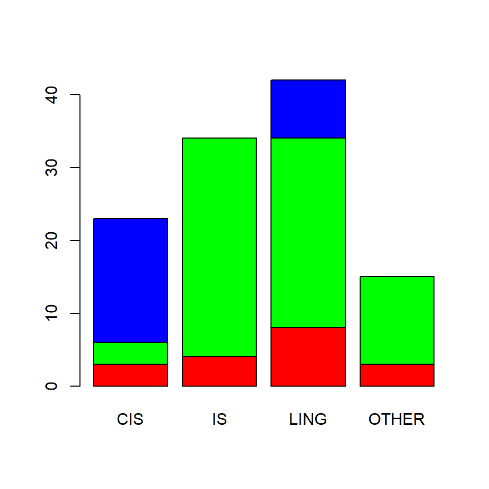

```r
barplot(counts, col=rainbow(3))
```

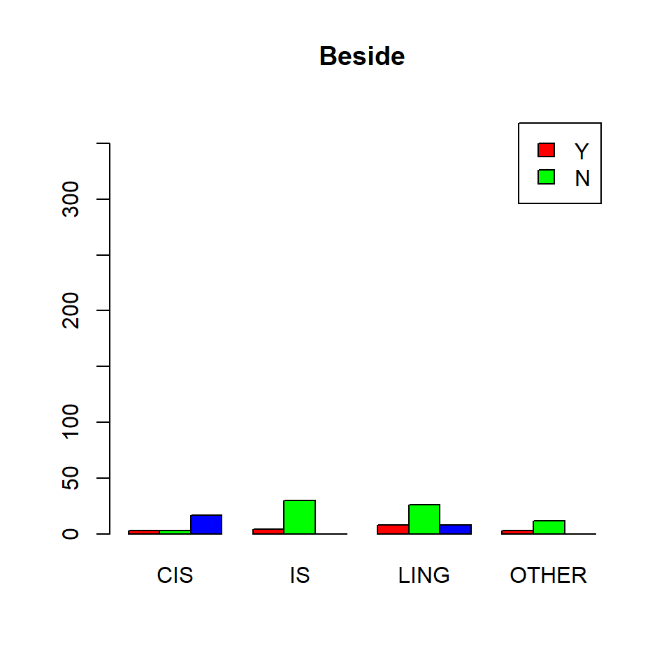

```r
barplot(counts, legend = c("Y", "N"), beside = T, ylim = c(0, 380), main = "Beside",col=rainbow(3))
```

We use a dataset wherein 315 students from the studies LING, CIS, IS etc. gave answers to the statistic questions. In this excercise we will try to see if there is a relationship between education level and the study of the 2017 group. The frequency of the combination is below 5. This is why we use Fisher’s exact test.

H0: There is no significant relationship between education level and the students chosen study. Ha: There is a significant relationship between education level and the students chosen study.

H0: $\mu$e = $\mu$s

Ha: $\mu$e $\neq$ $\mu$s

Significance level: 0.05

p-value: 2.608e-10

Cramer’s V : 0.485

The p-level is lower than the significance level. Therefor H0 will be rejected and we accept Ha.

The effectsize is rather big.

# 4 Excercise 4

```r
sats16 <- sats[sats$year == "2016", ]
satsQ <- c("Q5", "Q11", "Q26", "Q31", "Q32", "Q35", "math_grade")
satsQ2 <- c("Q5", "Q11", "Q26", "Q31", "Q32", "Q35")
satsCC <- sats16[satsQ]
satsCC_nomath <- sats16[satsQ2]
cor(satsCC$Q5, satsCC$math_grade, use = "pairwise.complete.obs")
```

```
## [1] -0.2063324
```

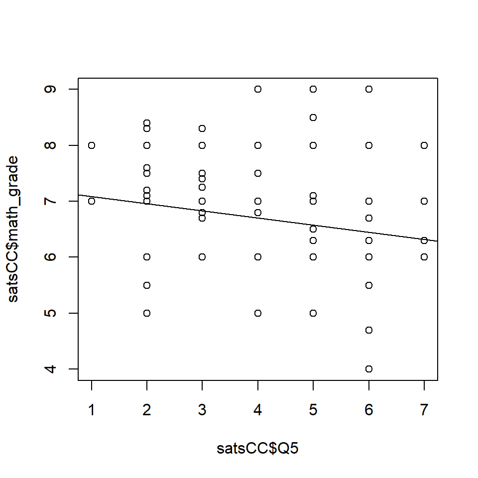

```r
plot(satsCC$Q5,satsCC$math_grade)
abline(lm(satsCC$math_grade ~ satsCC$Q5))
```

```r
cor(satsCC$Q11, satsCC$math_grade, use = "pairwise.complete.obs")
```

```
## [1] -0.07309921
```

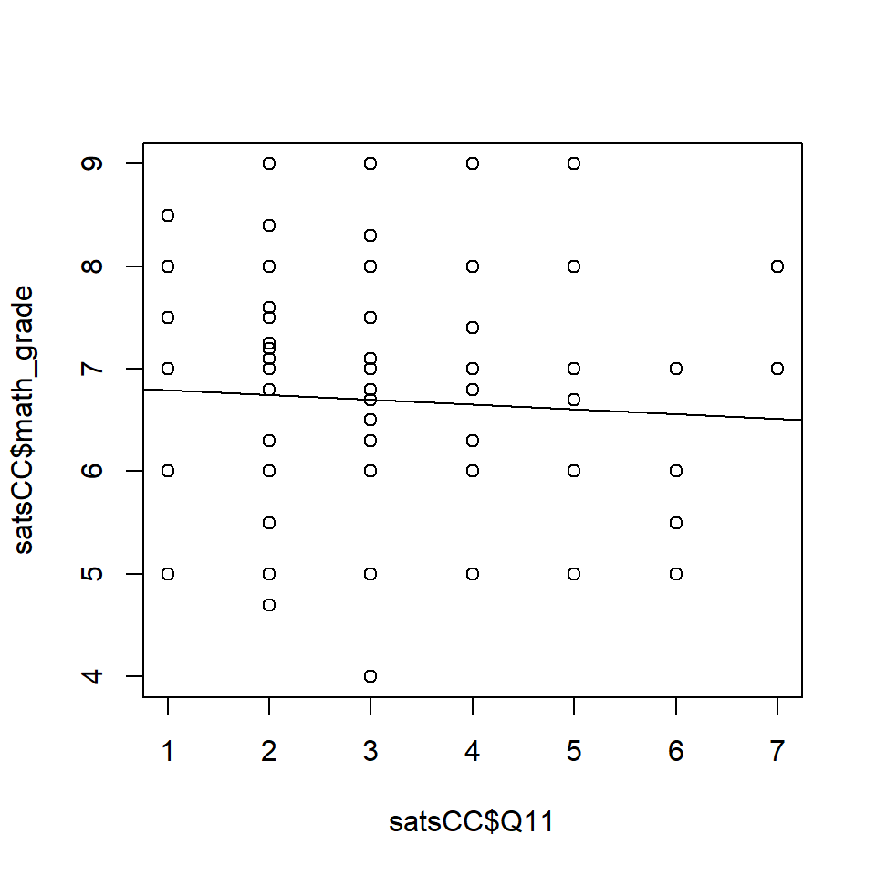

```r
plot(satsCC$Q11,satsCC$math_grade)
abline(lm(satsCC$math_grade ~ satsCC$Q11))
```

```r
cor(satsCC$Q26, satsCC$math_grade, use = "pairwise.complete.obs")
```

```
## [1] -0.2179397
```

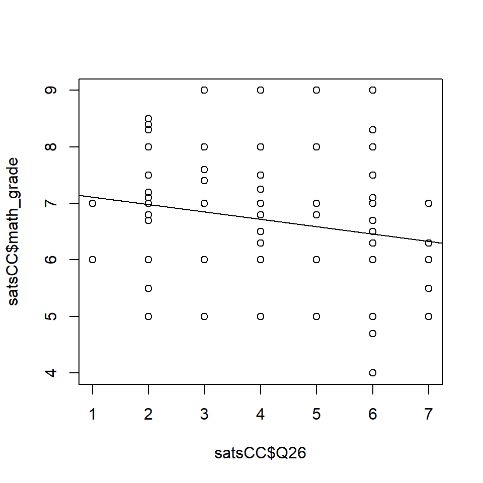

```r
plot(satsCC$Q26,satsCC$math_grade)
abline(lm(satsCC$math_grade ~ satsCC$Q26))
```

```r
cor(satsCC$Q31, satsCC$math_grade, use = "pairwise.complete.obs")
```

```
## [1] 0.1094676
```

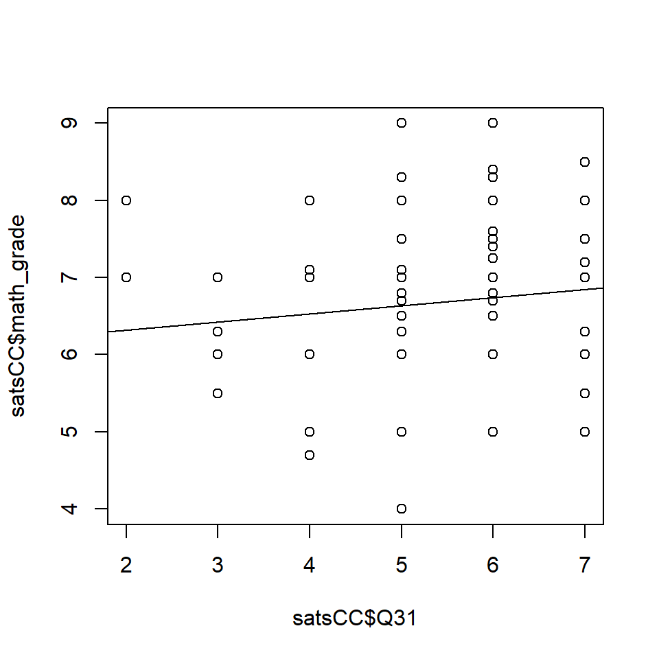

```r
plot(satsCC$Q31,satsCC$math_grade)
abline(lm(satsCC$math_grade ~ satsCC$Q31))
```

```r
cor(satsCC$Q32, satsCC$math_grade, use = "pairwise.complete.obs")
```

```
## [1] 0.07177237
```

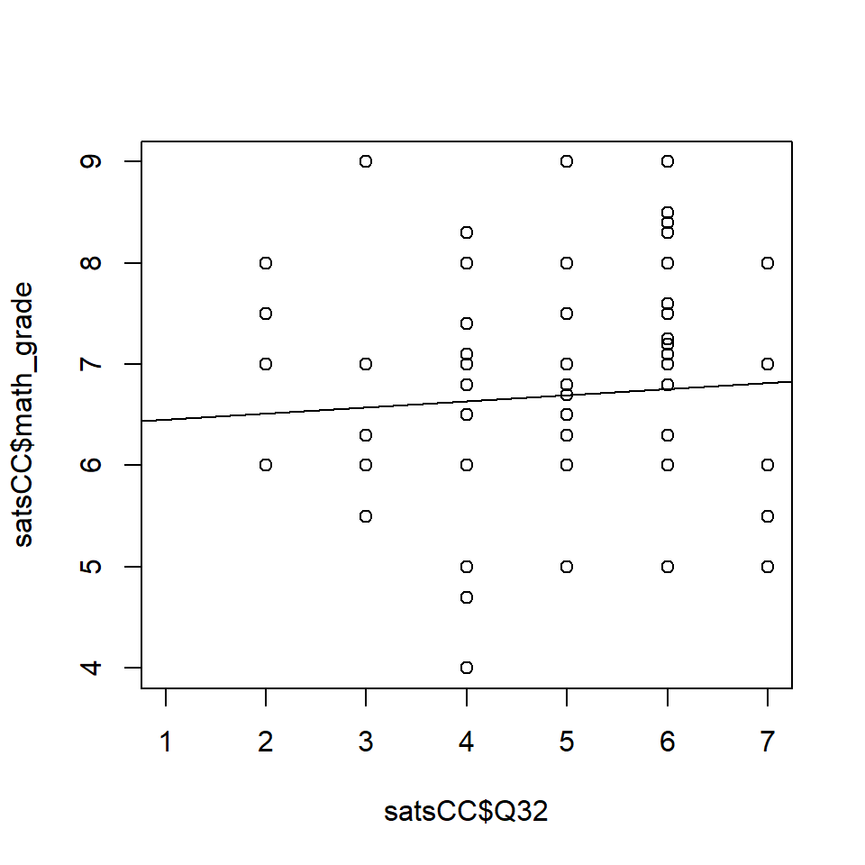

```r
plot(satsCC$Q32,satsCC$math_grade)
abline(lm(satsCC$math_grade ~ satsCC$Q32))
```

```r
cor(satsCC$Q35, satsCC$math_grade, use = "pairwise.complete.obs")
```

```
## [1] -0.200304
```

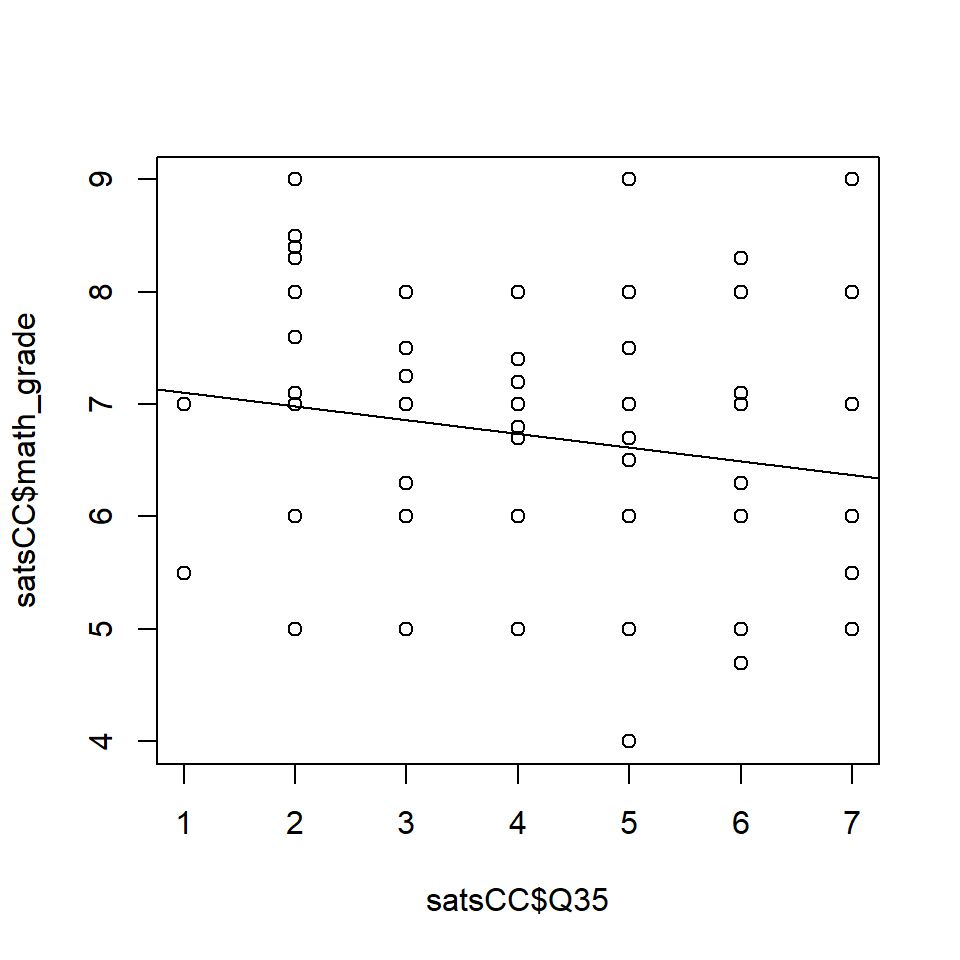

```r
plot(satsCC$Q35,satsCC$math_grade)
abline(lm(satsCC$math_grade ~ satsCC$Q35))
```

There is a negative relation with math_grade between the questions: “5, 11, 26, 35”. They are also inverted. This can bee seen back by looking at the sign in front of the questions and by looking at the questions themselfs in the sat test. There is a document which explains these questions.

# 5 Excercise 5

```r
library(psych)
(result <- alpha(satsCC))
```

```
## Some items ( Q31 Q32 math_grade ) were negatively correlated with the total scale and
## probably should be reversed.
## To do this, run the function again with the 'check.keys=TRUE' option
```

```
##
## Reliability analysis
## Call: alpha(x = satsCC)
##
##   raw_alpha std.alpha G6(smc) average_r   S/N   ase mean   sd
##       0.18     -0.13    0.36    -0.016 -0.11 0.077  4.7 0.53
##
##  lower alpha upper     95% confidence boundaries
## 0.03 0.18 0.33
##
##  Reliability if an item is dropped:
##            raw_alpha std.alpha G6(smc) average_r    S/N alpha se
## Q5            -0.194    -0.415    0.16    -0.051 -0.293    0.126
## Q11            0.025    -0.290    0.33    -0.039 -0.225    0.097
## Q26           -0.240    -0.438    0.16    -0.053 -0.305    0.132
## Q31            0.374     0.139    0.44     0.026  0.162    0.054
## Q32            0.457     0.225    0.46     0.046  0.290    0.047
## Q35           -0.232    -0.438    0.15    -0.054 -0.305    0.130
## math_grade     0.303     0.064    0.51     0.011  0.068    0.066
##
##  Item statistics
##              n  raw.r  std.r r.cor r.drop mean   sd
## Q5         196  0.707  0.569  0.64   0.41  4.1 1.48
## Q11        196  0.555  0.494  0.27   0.22  3.2 1.44
## Q26        196  0.732  0.581  0.66   0.44  4.2 1.52
## Q31        196 -0.118  0.105 -0.14  -0.36  5.5 0.95
## Q32        196 -0.220 -0.013 -0.30  -0.48  4.9 1.09
## Q35        196  0.732  0.581  0.67   0.44  4.4 1.47
## math_grade 188  0.015  0.195 -0.30  -0.22  6.7 0.90
```

```r
(summary(result))
```

```
##
## Reliability analysis
##  raw_alpha std.alpha G6(smc) average_r   S/N   ase mean   sd
##       0.18     -0.13    0.36    -0.016 -0.11 0.077  4.7 0.53
```

```
##  raw_alpha  std.alpha   G6(smc)   average_r        S/N       ase     mean
##   0.181637 -0.1260623 0.3586318 -0.01625274 -0.1119497 0.0769597 4.723311
##         sd
##  0.5302275
```

```r
(summary(alpha(satsCC, keys=c(-1,-1,-1,1,1,-1,1))))
```

```
##
## Reliability analysis
##  raw_alpha std.alpha G6(smc) average_r S/N   ase mean  sd
##       0.81       0.8    0.82      0.37 4.1 0.019  5.9 0.9
```

```
##  raw_alpha std.alpha   G6(smc) average_r      S/N        ase     mean
##  0.8090224 0.8046647 0.8203981 0.3704697 4.119401 0.01907924 5.869813
##         sd
##  0.9009463
```

```r
inversed <- alpha(satsCC_nomath, keys=c(-1,-1,-1,1,1,-1))
(summary(inversed))
```

```
##
## Reliability analysis
##  raw_alpha std.alpha G6(smc) average_r S/N   ase mean   sd
##       0.83      0.84    0.84      0.46 5.1 0.018  4.4 0.99
```

```
##  raw_alpha std.alpha   G6(smc) average_r      S/N        ase     mean
##  0.8286353 0.8368976 0.8421727 0.4609707 5.131119 0.01840094 4.412415
##         sd
##  0.9864374
```

```r
sats$satscomp <- ((8-sats$Q5)+(8-sats$Q11)+(8-sats$Q26)+sats$Q31+sats$Q32+(8-sats$Q35))/6
mean((sats$satscomp))
```

```
## [1] 4.484127
```

```r
cor(sats$satscomp, sats$math_grade, use = "pairwise.complete.obs")
```

```
## [1] 0.270721
```

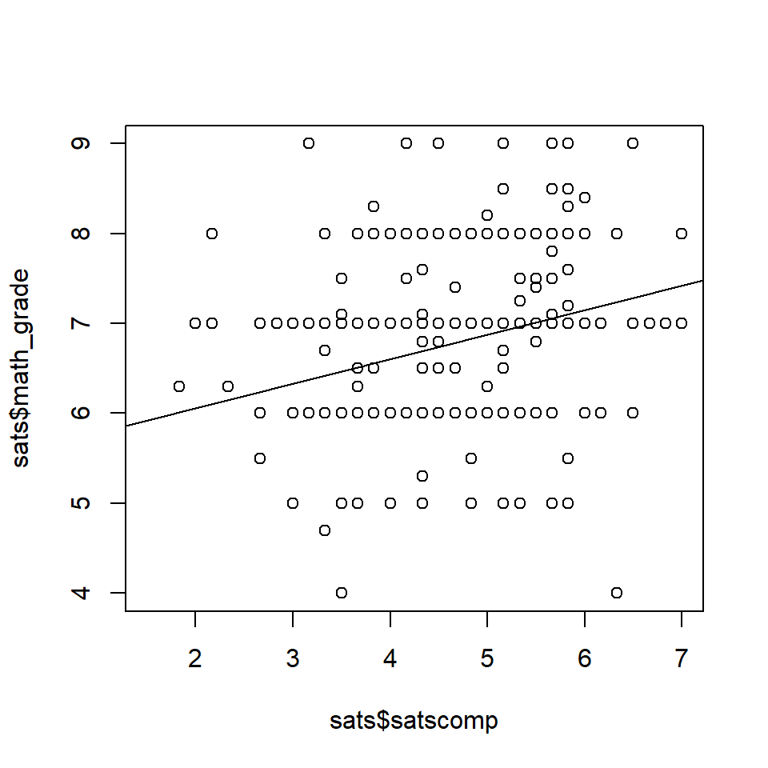

```r
plot(sats$satscomp, sats$math_grade)
abline(lm(sats$math_grade ~ sats$satscomp))
```

Without inverse results:

Reliability analysis raw_alpha: 0.18 std.alpha: -0.13 G6(smc): 0.36 average_r: -0.016 S/N: -0.11 ase: 0.077 mean: 4.7 sd: 0.53

There is a negative relation with math_grade between the questions: “5, 11, 26, 35”. They are also inverted. This can bee seen back by looking at the sign in front of the questions and by looking at the questions themselfs in the sat test. There is a document which explains these questions.

With inverse results:

Reliability analysis raw_alpha: 0.81 std.alpha:0.8 G6(smc): 0.82 average_r: 0.37 S/N: 4.1 ase: 0.019 mean: 5.9 sd: 0.9

If item should be excluded than I would leave math_grade out of the equation. These questions are about self perceived competence and therefor subjective. It isn’t about real competence.

Inverse without math_grade:

Reliability analysis raw_alpha: 0.83 std.alpha: 0.84 G6(smc): 0.84 average_r: 0.46 S/N: 5.1 ase: 0.018 mean: 4.4 sd: 0.99

With such a high raw_alpha we can state that this test is good.

Cor: 0.270721

The two stats could be slightly correlated. This is because math is about statistics but also a lot more different subjects. So if you are good in math than there is quite a good chance that you will be good in other area’s as well. Like statistics.

# 6 Excercise 6

```r
library(psych)
satsintelligence <- c("Q12", "Q20", "Q23", "Q29")
satsQ2 <- c("Q5", "Q11", "Q26", "Q31", "Q32", "Q35")
sc <- sats[satsQ2]
SATSintelligence <- sats[satsintelligence]
(result <- alpha(SATSintelligence))
```

```
##
## Reliability analysis
## Call: alpha(x = SATSintelligence)
##
##   raw_alpha std.alpha G6(smc) average_r S/N   ase mean  sd
##       0.87      0.87    0.85      0.63 6.7 0.012  4.9 1.1
##
##  lower alpha upper     95% confidence boundaries
## 0.84 0.87 0.89
##
##  Reliability if an item is dropped:
##     raw_alpha std.alpha G6(smc) average_r S/N alpha se
## Q12      0.87      0.88    0.83      0.70 7.2    0.012
## Q20      0.80      0.80    0.75      0.58 4.1    0.020
## Q23      0.82      0.82    0.77      0.60 4.6    0.018
## Q29      0.83      0.83    0.78      0.63 5.0    0.016
##
##  Item statistics
##       n raw.r std.r r.cor r.drop mean  sd
## Q12 315  0.78  0.78  0.66   0.61  4.5 1.3
## Q20 315  0.90  0.89  0.86   0.80  4.9 1.3
## Q23 315  0.86  0.87  0.82   0.76  5.3 1.1
## Q29 315  0.85  0.85  0.79   0.72  5.0 1.3
##
## Non missing response frequency for each item
##        1    2    3    4    5    6    7 miss
## Q12 0.02 0.06 0.10 0.32 0.25 0.22 0.03    0
## Q20 0.01 0.06 0.09 0.14 0.31 0.32 0.07    0
## Q23 0.00 0.03 0.04 0.11 0.34 0.40 0.08    0
## Q29 0.01 0.06 0.07 0.17 0.29 0.34 0.07    0
```

```r
(summary(result))
```

```
##
## Reliability analysis
##  raw_alpha std.alpha G6(smc) average_r S/N   ase mean  sd
##       0.87      0.87    0.85      0.63 6.7 0.012  4.9 1.1
```

```
##  raw_alpha std.alpha   G6(smc) average_r      S/N        ase    mean
##  0.8684353 0.8707193 0.8455449 0.6273907 6.735105 0.01212157 4.91746
##        sd
##  1.068668
```

```r
SATSintelligence$intelligencemean=rowMeans(SATSintelligence[,c("Q12", "Q20", "Q23", "Q29")], na.rm=TRUE)
cor(SATSintelligence$intelligencemean, sats$satscomp, use = "pairwise.complete.obs")
```

```
## [1] 0.2841911
```

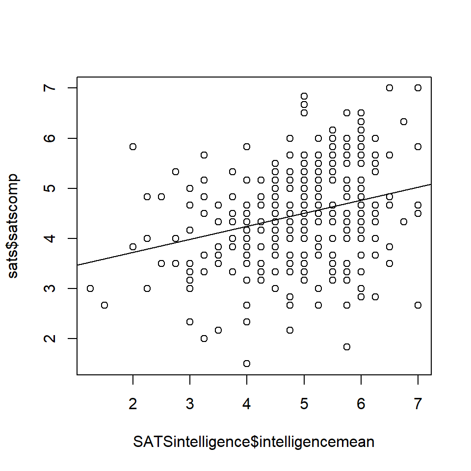

```r
plot(SATSintelligence$intelligencemean, sats$satscomp)
abline(lm(sats$satscomp ~ SATSintelligence$intelligencemean))
```

Reliability analysis raw_alpha: 0.87 std.alpha: 0.87 G6(smc): 0.85 average_r: 0.63 S/N: 6.7 ase: 0.012 mean: 4.9 sd: 1

The test has a high aplha so the test is good. Therefor there doesn’t have be a change in the number of questions. It can stay as it is.

Cronbac’s alpha depends on the following things. First of it needs the average correlation of all the variables for example questions. Secondly it needs the number of all the question. If you remove a question it can change the cronbach’s alpha. We can state the test is acceptable when the alpha is above 0.7, good when the alpha is above 0.8 and very good when the alpha is above 0.9. When the alpha is above 0.7 we can use the mean of the items as summary of the scale.

The two are correlated. This is because people who are interested in a specific subject will likely perform better than someone who isn’t interested. Therefor people who are interested in statistics will be more likely to say that they are better than they might are.